# Recommenderlab - Song Recommender System

# Theoretical Fundamentals

At the beginning of this document we would like to over you some theoretical fundamentals for recommender systems. This part was consciously added to this RMarkdown in order to over this script as a compact guide.

Most of the recommender systems are based on two different types of datasets. As you can see by the following image, we can distinguish between these two based on the occur of missing values.

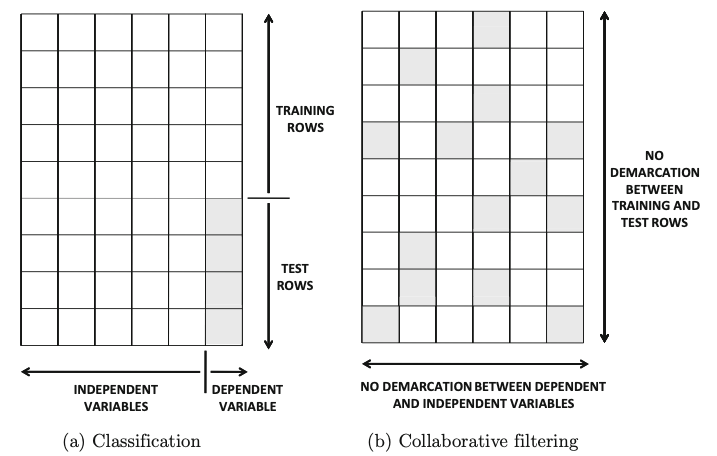

Image1 - Aggarwal, “Recommender Systems”

As we remember from the previous slides, in the dataset of our project around 494 missing values have to be consider. Due to this high number, a prediction in terms of classification is not possible.

Even though we captured to work with a collaborative filtering, additional aspects have to be clarified. Again, based on the characteristics of our dataset we made further decisions, which leads us in the end to a recommender system which will be computed by a **collaborative filtering that is user based**.

Last but not least we have to classify which distance measurement we would like to use for our user based - collaborative filtering algorithm. Possible measures would be the “cosine-distance” or a correlation based distance measure via the “pearson-correlation-coefficient”. The following image can give you a first idea of these measurements in the case of collaborative filtering.

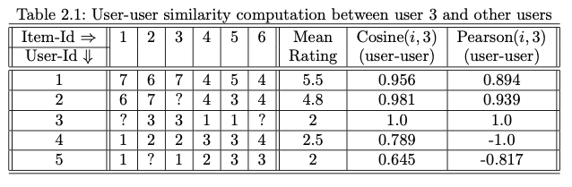

Image2 - Aggarwal, “Recommender Systems”

If we consider the intersection and the formula for the pearson-correlation-coefficient, we get the following calculation:

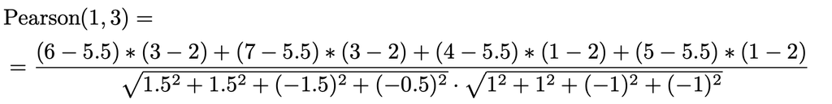

# The Code for the Recommender Systems

After talking about the theoretical fundamentals, we now can start with the code for our recommender system. The following packages will be used:

```r
library(recommenderlab)
library(readr)
library(tidyverse)
```

In next step we will read in our dataframe that have to be pre-processed in order to be converted to an **realRatingMatrix**. This matrix is an object out of the recommenderlab package:

```r
final_df <- read_csv("final_df.csv")
final_df[-1] <- na_if(final_df[-1], 1)

final_df <- as.matrix(final_df[,-1])
rownames(final_df) <- paste0("u", 1:120)
colnames(final_df) <- paste0("i", 1:50)
r <- as(final_df, "realRatingMatrix")
r
```

```
## 120 x 50 rating matrix of class 'realRatingMatrix' with 5506 ratings.
```

## Inspection of data set

General understanding of the object:

```r
str(r)
```

```
## Formal class 'realRatingMatrix' [package "recommenderlab"] with 2 slots
##   ..@ data     :Formal class 'dgCMatrix' [package "Matrix"] with 6 slots
##   .. .. ..@ i       : int [1:5506] 0 1 2 3 4 5 6 7 8 9 ...
##   .. .. ..@ p       : int [1:51] 0 119 237 356 471 587 707 823 939 1049 ...
##   .. .. ..@ Dim     : int [1:2] 120 50
##   .. .. ..@ Dimnames:List of 2
##   .. .. .. ..$ : chr [1:120] "u1" "u2" "u3" "u4" ...
##   .. .. .. ..$ : chr [1:50] "i1" "i2" "i3" "i4" ...
##   .. .. ..@ x       : num [1:5506] 6 6 7 2 2 2 6 7 6 6 ...
##   .. .. ..@ factors : list()
##   ..@ normalize: NULL
```

```r
identical(as(r, "matrix"),final_df)
```

```
## [1] TRUE
```

```r
r_sample <- as(sample(r, 5), "list")
r_sample
```

```
## $u100
##  i1  i2  i3  i4  i5  i6  i7  i9 i10 i11 i12 i13 i15 i16 i17 i18 i21 i22
##   6   6   6   7   6   6   6   6   6   6   6   7   6   6   6   6   6   6
## i23 i26 i29 i30 i31 i32 i33 i34 i35 i36 i37 i38 i39 i40 i41 i42 i43 i44
##   3   6   6   7   6   6   6   6   6   6   6   6   6   6   7   6   3   6
## i45 i46 i47 i48 i49 i50
##   6   3   6   7   6   3
##
## $u16
##  i1  i2  i3  i4  i5  i6  i7  i8  i9 i10 i11 i12 i13 i14 i15 i16 i17 i18
##   7   5   5   6   6   6   6   6   7   5   6   5   5   2   6   2   4   5
## i19 i20 i21 i22 i23 i24 i25 i26 i27 i28 i29 i30 i31 i32 i33 i34 i35 i36
##   6   4   6   3   6   6   5   2   4   2   5   6   5   7   6   6   5   5
## i37 i38 i39 i40 i41 i42 i43 i44 i45 i46 i47 i48 i49 i50
##   6   2   6   6   6   2   6   5   5   2   2   5   2   2
##
## $u46
##  i1  i2  i3  i4  i5  i6  i7  i8  i9 i10 i11 i12 i13 i14 i15 i16 i17 i18
##   6   7   6   6   6   4   3   5   7   5   6   4   3   3   5   3   6   6
## i19 i20 i21 i22 i23 i24 i25 i26 i27 i29 i30 i31 i32 i33 i34 i35 i36 i37
##   7   7   6   2   2   4   6   6   6   2   3   3   7   3   7   6   5   2
## i38 i39 i40 i41 i42 i43 i44 i45 i47 i48 i49 i50
##   7   2   2   3   5   4   5   5   3   3   6   6
##
## $u9
##  i1  i2  i3  i4  i5  i6  i7  i8  i9 i10 i11 i12 i13 i14 i15 i16 i17 i18
##   6   4   6   6   3   6   7   4   6   7   6   3   7   6   6   6   6   7
## i19 i21 i23 i24 i25 i26 i27 i29 i30 i31 i32 i33 i34 i35 i36 i37 i38 i39
##   4   4   3   6   4   6   4   4   7   4   7   6   3   4   7   4   7   4
## i40 i41 i42 i43 i44 i45 i46 i47 i48 i49 i50
##   3   3   6   6   7   7   3   4   4   7   7
##
## $u77
##  i1  i2  i3  i4  i5  i6  i7  i8  i9 i10 i11 i12 i13 i14 i15 i17 i18 i22
##   7   7   7   7   7   7   6   7   7   7   7   7   6   7   7   7   7   6
## i23 i24 i26 i27 i29 i30 i31 i32 i33 i34 i35 i36 i37 i38 i39 i40 i41 i42
##   6   7   6   7   7   7   7   7   7   7   7   7   2   7   7   7   7   7
## i43 i44 i45 i46 i47 i48 i49 i50
##   7   7   7   7   7   7   7   7
```

```r
rowMeans(sample(r, 5))
```

```
##      u59     u103      u99      u70     u116
## 5.422222 5.220000 5.489362 4.840000 6.387755
```

Histgramme:

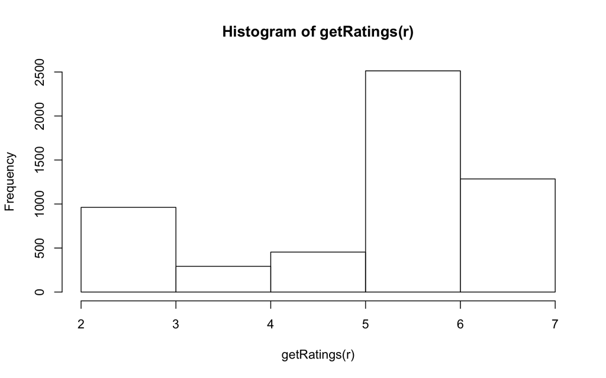

```r
hist(getRatings(r), breaks=5)
```

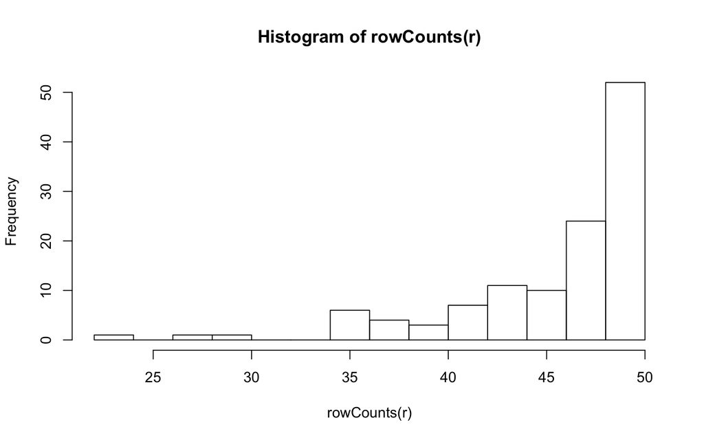

```r
hist(rowCounts(r), breaks=15)
```

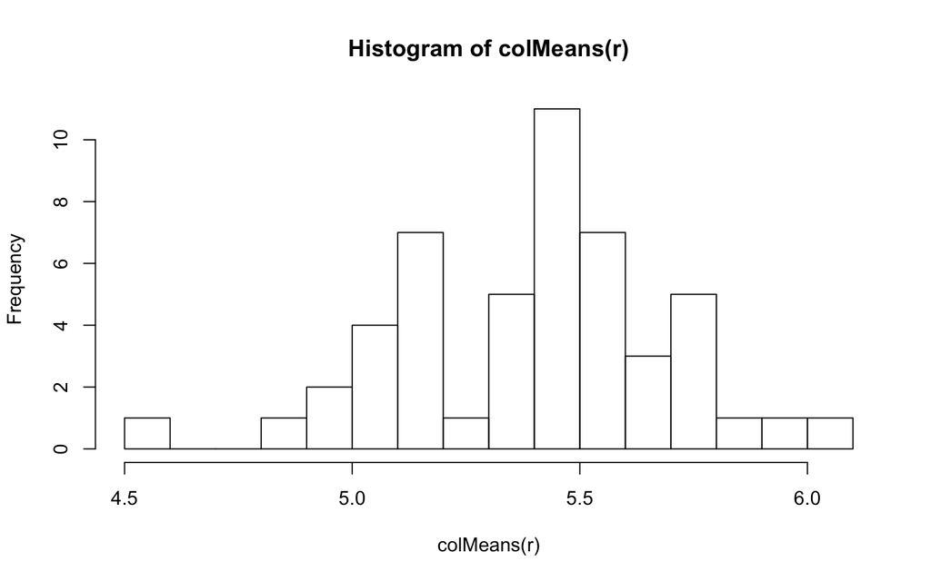

```r
hist(colMeans(r), breaks=15)
```

# Creating a recommender

By using the function **Recommender()** we create the object **recommenderRegistry** which can be used for different kind of recommender systems. Depending on the characteristics of you dataframe you have to check which options you would like to use.

```r
recommenderRegistry$get_entries(dataType = "realRatingMatrix")
```

```
## $HYBRID_realRatingMatrix
## Recommender method: HYBRID for realRatingMatrix
## Description: Hybrid recommender that aggegates several recommendation strategies using weighted averages.
## Reference: NA
## Parameters:
##   recommenders weights
## 1         NULL    NULL
##
## $ALS_realRatingMatrix
## Recommender method: ALS for realRatingMatrix
## Description: Recommender for explicit ratings based on latent factors, calculated by alternating least squares algorithm.
## Reference: Yunhong Zhou, Dennis Wilkinson, Robert Schreiber, Rong Pan (2008). Large-Scale Parallel Collaborative Filtering for the Netflix Prize, 4th Int'l Conf. Algorithmic Aspects in Information and Management, LNCS 5034.
## Parameters:
##   normalize lambda n_factors n_iterations min_item_nr seed
## 1      NULL    0.1        10           10           1 NULL
##
## $ALS_implicit_realRatingMatrix
## Recommender method: ALS_implicit for realRatingMatrix
## Description: Recommender for implicit data based on latent factors, calculated by alternating least squares algorithm.
## Reference: Yifan Hu, Yehuda Koren, Chris Volinsky (2008). Collaborative Filtering for Implicit Feedback Datasets, ICDM '08 Proceedings of the 2008 Eighth IEEE International Conference on Data Mining, pages 263-272.
## Parameters:
##   lambda alpha n_factors n_iterations min_item_nr seed
## 1    0.1    10        10           10           1 NULL
##
## $IBCF_realRatingMatrix
## Recommender method: IBCF for realRatingMatrix
## Description: Recommender based on item-based collaborative filtering.
## Reference: NA
## Parameters:
##    k   method normalize normalize_sim_matrix alpha na_as_zero
## 1 30 "Cosine"  "center"                FALSE   0.5      FALSE
##
## $LIBMF_realRatingMatrix
## Recommender method: LIBMF for realRatingMatrix
## Description: Matrix factorization with LIBMF via package recosystem (https://cran.r-project.org/web/packages/recosystem/vignettes/introduction.html).
## Reference: NA
## Parameters:
##   dim costp_l2 costq_l2 nthread
## 1  10     0.01     0.01       1
##
```

[output cut: 36 more lines]

```
## Description: Recommender based on Funk SVD with gradient descend (https://sifter.org/~simon/journal/20061211.html).
## Reference: NA
## Parameters:
##    k gamma lambda min_epochs max_epochs min_improvement normalize verbose
## 1 10 0.015  0.001         50        200           1e-06  "center"   FALSE
##
## $UBCF_realRatingMatrix
## Recommender method: UBCF for realRatingMatrix
## Description: Recommender based on user-based collaborative filtering.
## Reference: NA
## Parameters:
##     method nn sample weighted normalize min_matching_items
## 1 "cosine" 25  FALSE     TRUE  "center"                  0
##   min_predictive_items
## 1                    0
```

## User-Based Collaborative Filtering Model (UBCF)

This time we use the recommender method “UBCF” out of realRatingMatrix. Therefore, we generate a recommender based on user-based collaborative filtering:

```r
r_model_2 <- Recommender(r[1:120], method = "UBCF",
  param=list(method="pearson"))

#r_model_2
#names(getModel(r_model_2))
#getModel(r_model_2)$method
```

### Recommendations

Recommendations are generated by **predict()**. In this example we are offering the top 15 recommendation for user. In case the user is only unfamiliar with less than 15 Song, the prediction only covers the remaining ones.

```r
recom2 <- predict(r_model_2, r[c(39,100,101,5)], n=15)
recom2
```

```
## Recommendations as 'topNList' with n = 15 for 4 users.
```

```r
as(recom2, "list")
```

```
## $u39
## [1] "i41"
##
## $u100
## [1] "i8"  "i14" "i27" "i25" "i20" "i19" "i24" "i28"
##
## $u101
## [1] "i25" "i27" "i24" "i20"
##
## $u5
##  [1] "i5"  "i7"  "i9"  "i49" "i17" "i21" "i33" "i4"  "i40" "i12" "i50"
## [12] "i43" "i13" "i27" "i45"
```

## A second example of a possible model

Another option we could test for our system would be the **popularity model**. In this case we generate a system that is focused on the popularity of an item (song with highest number of users which have the song in their profile). This approach then would represent an item-based approach because instead of compute calculations over the observations we now compare the columns.

```r
r_model <- Recommender(r[1:120], method = "POPULAR")
r_model
```

```
## Recommender of type 'POPULAR' for 'realRatingMatrix'
## learned using 120 users.
```

```r
recom <- predict(r_model, r[c(39,100,101,5)], n=15)
recom
```

```
## Recommendations as 'topNList' with n = 15 for 4 users.
```

```r
as(recom, "list")
```

```
## $u39
## [1] "i41"
##
## $u100
## [1] "i8"  "i27" "i14" "i25" "i20" "i24" "i19" "i28"
##
## $u101
## [1] "i27" "i25" "i20" "i24"
##
## $u5
##  [1] "i7"  "i9"  "i45" "i4"  "i42" "i5"  "i13" "i43" "i49" "i21" "i17"
## [12] "i15" "i33" "i12" "i46"
```

For further inspirations please have a look into the documentation of the recommenderlab package: https://cran.r-project.org/web/packages/recommenderlab/vignettes/recommenderlab.pdf)

Robert Weber und Alexander Kleine

6/25/2020